# Higher Jesuit Education

Maya Fraser-Philbin & Tom Bastasch

December 14, 2015

```r
library(tidyr)
library(ggplot2)
library(countrycode)
suppressPackageStartupMessages(library(dplyr))
suppressPackageStartupMessages(library(xlsx))
suppressPackageStartupMessages(library(htmlwidgets))
library(taucharts)
library(choroplethr)
library(choroplethrMaps)
suppressPackageStartupMessages(library(DT))
setwd("~/")
jc <- read.xlsx('JesuitColleges.xlsx',1)
```

# Introduction

We broke our study down into three perspectives: regional, country by country and general institution. We are exploring the relationships between the variables of Alumni, Instution numbers, staff numbers and undergraduate enrollment.

## Regional Breakdown

```r
reg <- jc %>% group_by(Region) %>% summarize(Instituions = length(Region), Alumreg = sum(Alumni), Undergradreg = sum(Undergraduate.Enrollment))
rb = datatable(reg,options = list(
  autowidth = TRUE,
  order = list(
    list(2, "desc")
  )))
saveWidget(rb,file = "rb.html",selfcontained = TRUE)
```

[interactive chart not shown]

South Asia has the most institutions(53)  
North America has the most Alumni (1,560,401)  
Latin America has the largest undergrad population(126,795)

## Country Breakdown

### Which Country has the most Jesuit institutions?

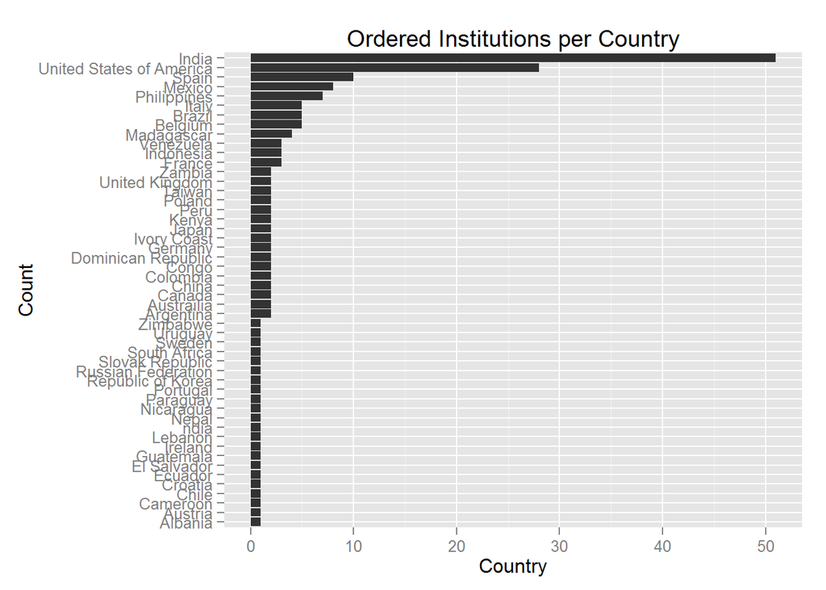

```r
cc <- jc %>% group_by(Country) %>% summarize(Countrycount = length(Country))
ggplot(cc, aes(x = reorder(Country, Countrycount), y = Countrycount)) + geom_bar(stat = "identity") + coord_flip() + labs(y = "Country", x = "Count", title = "Ordered Institutions per Country")
```

India, U.S. and Spain have the most institutions

### Which Country has the most undergrad students?

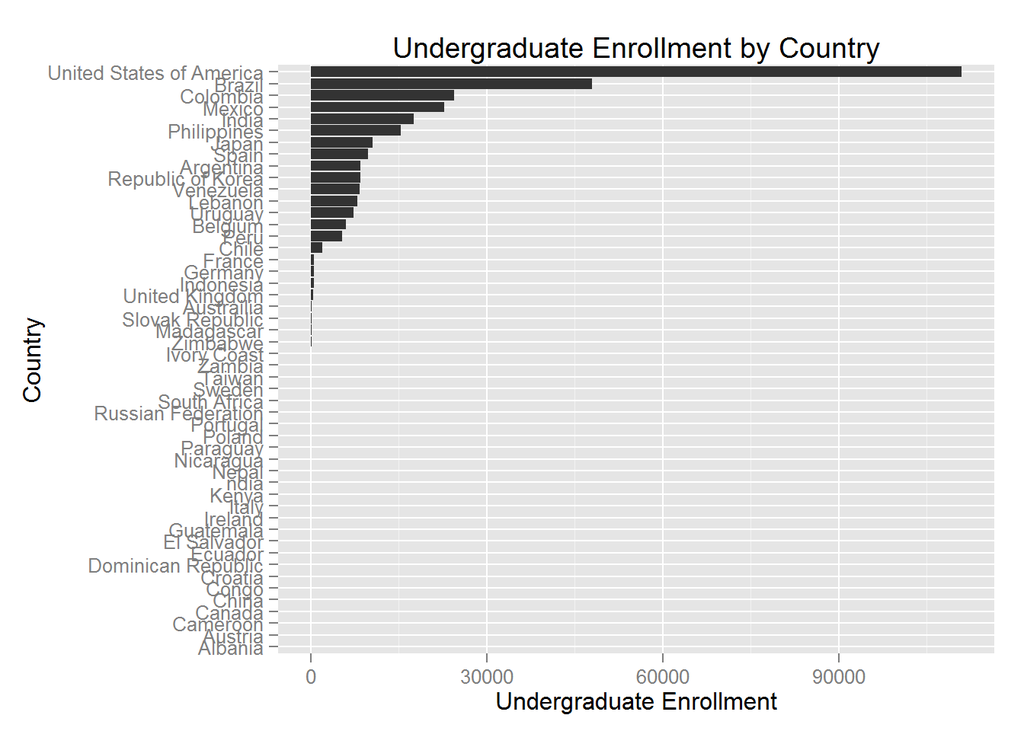

```r
ugct <- jc %>% group_by(Country) %>% summarize(Undercount = sum(Undergraduate.Enrollment))

ggplot(ugct, aes(x = reorder(Country, Undercount), y = Undercount)) + geom_bar(stat = "identity") + coord_flip() + labs(y = "Undergraduate Enrollment", x = "Country", title = "Undergraduate Enrollment by Country")
```

U.S., Brazil and Colombia have the largest undergrad population

```r
ac <- jc %>% group_by(Country) %>% summarize(Alumcount = sum(Alumni))
colnames(ac)=c("region","value")
ac <- data.frame(lapply(ac, function(v) {
  if(!is.numeric(v)) return(tolower(v))
  else return(v)
}), stringsAsFactors = FALSE)
ac[3,1]="australia"
ac[40,1]="slovakia"
ac[12,1]="democratic republic of the congo"
ac[38,1]="south korea"
ac[39,1]="russia"

alum = country_choropleth(ac, title = "Alumni/Country Colored Map")
```

### Which countries have the most graduates?

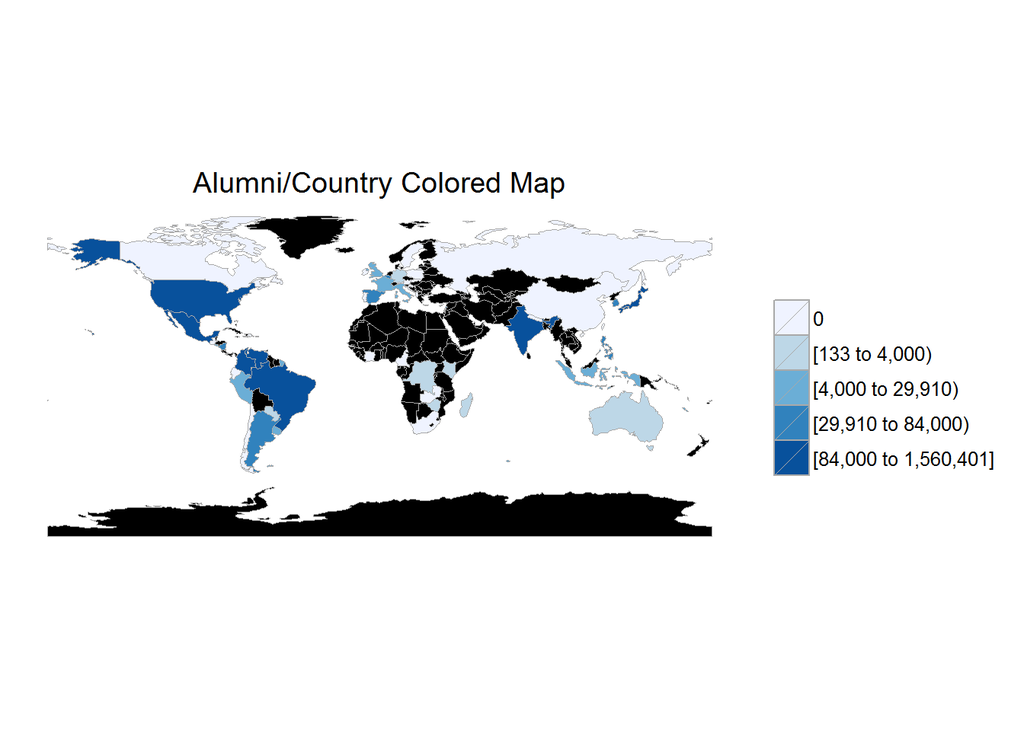

```r
alum
```

Top 3: U.S., India and Brazil

## General Breakdown

### Breakdown of Staff to undergrad

```r
stg = jc %>% tauchart(height=500,width=900)%>%
  tau_point(x="Undergraduate.Enrollment",y="Staff",color="Name")%>%
  tau_tooltip(c("Undergraduate.Enrollment","Staff","Name"))%>%
  tau_guide_y(auto_scale=FALSE)%>%
  tau_guide_x(auto_scale=FALSE)%>%tau_legend()
saveWidget(stg,file = "stg.html",selfcontained = TRUE)
```

[interactive chart not shown]

Universidade do Vale do Rios do Sinos (UNISINOS) has the most undergrad students per staff members… around a 12:1 ratio respectively.  
Escola Superior de Administração Direito e Economia (ESADE) is the opposite story with a student to faculty ratio of 8:3

# Conclusion

Regionally, it seems as though Latin America is embracing Jesuit Institutions while North America and Southern Asia have an established Jesuit Presence (extrapolated from the high Alumni/Instutional numbers for Asia and North America versus the High Undergrad population in Latin America).

From the Country perspective, the U.S has a strong emerging and established Jesuit presence while India has the most institutions established.

Part of the appeal of attending a Jesuit University is the balanced student to faculty ratio. Schools such as Gonzaga (around a 4:1 ratio) or ESADE are preferrable over UNISINOS.

# Limitations

The data had many unreported, missing or incorrect values - many times staff was reported without undergrad or vice versa. Other issues included symbols in instution names and N/A values.